# Part I - Ford GoBike System Data Exploration

## Introduction

> This report presents data exploration of the Ford GoBike System data. This data was provided by udacity via a [link](https://video.udacity-data.com/topher/2020/October/5f91cf38_201902-fordgobike-tripdata/201902-fordgobike-tripdata.csv) and was used to develop this project. The data was downloaded programatically using python `requests` library and was then read into pandas dataframe. This dataset conveyed information regarding individual rides that were made in a bike-sharing system. In particular, this data was from the greater San Francisco Bay area. The main aim of this project was to utilize univariate, bivariate, and multivariate visualizations to gain hidden insights into the data.

## Preliminary Wrangling

```python
# import all packages and set plots to be embedded inline
import numpy as np
import pandas as pd
import matplotlib.pyplot as plt
import seaborn as sns

#supress all warnings
import warnings
warnings.filterwarnings('ignore')

%matplotlib inline
```

> Load dataset and describe its properties

```python
# download the data using the requests.get() method
import requests
url="https://video.udacity-data.com/topher/2020/October/5f91cf38_201902-fordgobike-tripdata/201902-fordgobike-tripdata.csv"
response=requests.get(url)
with open('201902-fordgobike-tripdata.csv', mode ='wb') as file:
    file.write(response.content)
```

```python
#load the data using pandas and view the first five rows
bike_data = pd.read_csv('201902-fordgobike-tripdata.csv')
#make a copy of the data to avoid altering the original dataset
bike = bike_data.copy()
```

```python
#view the shape of the data
print(bike.shape)
#check for data types and missing values
print(bike.info())
#count the number of missing values per column
print(bike.isnull().sum())
#check for duplicate
print(bike.duplicated().sum())
```

```
(183412, 16)
<class 'pandas.core.frame.DataFrame'>
RangeIndex: 183412 entries, 0 to 183411
Data columns (total 16 columns):
duration_sec               183412 non-null int64
start_time                 183412 non-null object
end_time                   183412 non-null object
start_station_id           183215 non-null float64
start_station_name         183215 non-null object
start_station_latitude     183412 non-null float64
start_station_longitude    183412 non-null float64
end_station_id             183215 non-null float64
end_station_name           183215 non-null object
end_station_latitude       183412 non-null float64
end_station_longitude      183412 non-null float64
bike_id                    183412 non-null int64
user_type                  183412 non-null object
member_birth_year          175147 non-null float64
member_gender              175147 non-null object
bike_share_for_all_trip    183412 non-null object
dtypes: float64(7), int64(2), object(7)
memory usage: 22.4+ MB
None
duration_sec                  0
start_time                    0
end_time                      0
start_station_id            197
start_station_name          197
start_station_latitude        0
start_station_longitude       0
end_station_id              197
end_station_name            197
end_station_latitude          0
end_station_longitude         0
bike_id                       0
user_type                     0
member_birth_year          8265
member_gender              8265
bike_share_for_all_trip       0
dtype: int64
0
```

```python
#drop rows with missing values
bike.dropna(inplace=True, axis=0)

#convert `bike_id`, `start_station_id`,  `end_station_id` into string data types
bike['start_station_id'] =bike['start_station_id'].astype(str)
bike['end_station_id'] =bike['end_station_id'].astype(str)
bike['bike_id'] =bike['bike_id'].astype(str)
#convert member birth year from float to int
bike['member_birth_year']=bike['member_birth_year'].astype(int)
#convert duration_sec to float
bike['duration_sec']=bike['duration_sec'].astype(float)


#convert start_time and end_time to data time format
bike['start_time'] = pd.to_datetime(bike['start_time'])
bike['end_time'] = pd.to_datetime(bike['end_time'])

##convert start_time to hours, days, month and year
bike['start_day'] = bike['start_time'].dt.day_name()
bike['start_month'] = bike['start_time'].dt.month_name()
#bike['start_year'] = bike['start_time'].dt.year
##convert end_time to hours, days, month and year

bike['end_day'] = bike['end_time'].dt.day_name()
bike['end_month'] = bike['end_time'].dt.month_name()
#bike['end_year'] = bike['end_time'].dt.year

#calculate the age of the participants when this trip started.
bike['age']=(2019-bike.member_birth_year)
```

```python
#recheck the data types and shape
print(bike.dtypes)
print(bike.shape)
```

```
duration_sec                      float64
start_time                 datetime64[ns]
end_time                   datetime64[ns]
start_station_id                   object
start_station_name                 object
start_station_latitude            float64
start_station_longitude           float64
end_station_id                     object
end_station_name                   object
end_station_latitude              float64
end_station_longitude             float64
bike_id                            object
user_type                          object
member_birth_year                   int64
member_gender                      object
bike_share_for_all_trip            object
start_day                          object
start_month                        object
end_day                            object
end_month                          object
age                                 int64
dtype: object
(174952, 21)
```

```python
#descriptive statistics for numeric variables
bike.describe()
```

|  | duration_sec | start_station_latitude | start_station_longitude | end_station_latitude | end_station_longitude | member_birth_year | age |
| --- | --- | --- | --- | --- | --- | --- | --- |
| count | 174952.000000 | 174952.000000 | 174952.000000 | 174952.000000 | 174952.000000 | 174952.000000 | 174952.000000 |
| mean | 704.002744 | 37.771220 | -122.351760 | 37.771414 | -122.351335 | 1984.803135 | 34.196865 |
| std | 1642.204905 | 0.100391 | 0.117732 | 0.100295 | 0.117294 | 10.118731 | 10.118731 |
| min | 61.000000 | 37.317298 | -122.453704 | 37.317298 | -122.453704 | 1878.000000 | 18.000000 |
| 25% | 323.000000 | 37.770407 | -122.411901 | 37.770407 | -122.411647 | 1980.000000 | 27.000000 |
| 50% | 510.000000 | 37.780760 | -122.398279 | 37.781010 | -122.397437 | 1987.000000 | 32.000000 |
| 75% | 789.000000 | 37.797320 | -122.283093 | 37.797673 | -122.286533 | 1992.000000 | 39.000000 |
| max | 84548.000000 | 37.880222 | -121.874119 | 37.880222 | -121.874119 | 2001.000000 | 141.000000 |

```python
# member age of 1878 is not realistic. Maybe it was due to typing error. Let's further investigate the case
bike.query('member_birth_year==1878')
```

|  | duration_sec | start_time | end_time | start_station_id | start_station_name | start_station_latitude | start_station_longitude | end_station_id | end_station_name | end_station_latitude | ... | bike_id | user_type | member_birth_year | member_gender | bike_share_for_all_trip | start_day | start_month | end_day | end_month | age |
| --- | --- | --- | --- | --- | --- | --- | --- | --- | --- | --- | --- | --- | --- | --- | --- | --- | --- | --- | --- | --- | --- |
| 27370 | 1474.0 | 2019-02-25 09:28:42.161 | 2019-02-25 09:53:17.068 | 15.0 | San Francisco Ferry Building (Harry Bridges Pl... | 37.795392 | -122.394203 | 386.0 | 24th St at Bartlett St | 37.752105 | ... | 6436 | Customer | 1878 | Female | No | Monday | February | Monday | February | 141 |

1 rows × 21 columns

```python
#it is most likely that this value should be 1978 instead of 1878. Thus, we replace the value with 1978
for i in bike.member_birth_year.values:
    if i ==1878:
        bike.replace(i, 1978, inplace=True)
#check whether the value is replaced
bike.query('member_birth_year==1878')
```

|  | duration_sec | start_time | end_time | start_station_id | start_station_name | start_station_latitude | start_station_longitude | end_station_id | end_station_name | end_station_latitude | ... | bike_id | user_type | member_birth_year | member_gender | bike_share_for_all_trip | start_day | start_month | end_day | end_month | age |
| --- | --- | --- | --- | --- | --- | --- | --- | --- | --- | --- | --- | --- | --- | --- | --- | --- | --- | --- | --- | --- | --- |

0 rows × 21 columns

```python
## convert day, and months into ordered categorical types
ordered_dict ={'start_day':['Monday', 'Tuesday', 'Wednesday', 'Thursday', 'Friday', 'Saturday'],
               'end_day':['Monday', 'Tuesday', 'Wednesday', 'Thursday', 'Friday', 'Saturday'],
                'start_month':['January', 'February', 'March'],
                'end_month':['January', 'February', 'March']}
for var in ordered_dict:
    ordered_var=pd.api.types.CategoricalDtype(ordered = True, categories =ordered_dict[var])
    bike[var]=bike[var].astype(ordered_var)
```

### What features in the dataset do you think will help support your investigation into your feature(s) of interest?

> The following features will be helpful in supporting this investigation
> - duration_sec
> - user_type
> - member_birth_year
> - member_gender
> - bike_share_for_all_trip
> - start_day
> - end_day

## Univariate Exploration

> In this section, I investigated distributions of individual variables. This aimed to identify unusual points and outliers to allow for additional data cleaning.

I will start by looking at the distribution of duration in sec

```python
#create a function that gives the xlabel, ylabel and title to any graph
def x_y_t(Xlab, Ylab, title):
    plt.title(title)
    plt.xlabel(Xlab)
    plt.ylabel(Ylab)
```

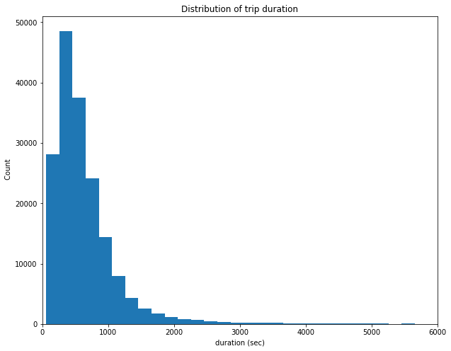

```python
bins= np.arange(61, bike.duration_sec.max()+200, 200)
plt.figure(figsize=(10, 8))
plt.hist(data=bike, x = 'duration_sec', bins=bins)
plt.xlim(0, 6000)
x_y_t('duration (sec)',' Count', 'Distribution of trip duration')
plt.show()
```

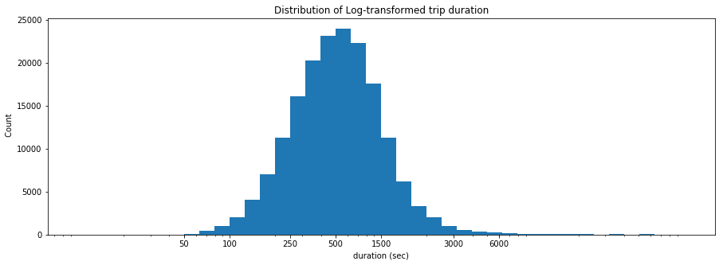

```python
# there's a long tail in the distribution, so let's put it on a log scale instead
bins= 10**np.arange(1, 5+0.1, 0.1)
#set figure size
plt.figure(figsize=(15, 5))
plt.hist(data=bike, x = 'duration_sec', bins=bins)
plt.xscale('log')
x_y_t('duration (sec)',' Count', 'Distribution of Log-transformed trip duration')
plt.xticks([50, 100, 250, 500, 1000, 3000, 6000],[50, 100,250, 500, 1500, 3000, 6000])
plt.show()
```

> Duration in seconds has a long-tailed distribution and was skewed to right. This implies that the highest number of participants took lesser time (seconds) to complete the trip, while few participants took longer time to complete the trip. When plotted on a log-scale, the distribution of the duration of time looks unimodal with peak between 400 and 1000.

> next, we look at start day and end day of the trips

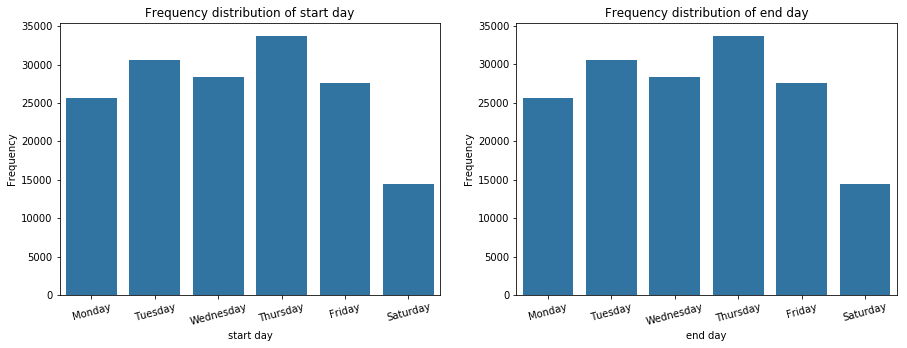

```python
base_color = sns.color_palette()[0]

plt.figure(figsize = [15, 5])
plt.subplot(1,2, 1)
sns.countplot(data=bike, x='start_day', color=base_color)
plt.xticks(rotation = 15)
#add xlabel, ylabel and title
x_y_t('start day', 'Frequency', 'Frequency distribution of start day')



plt.subplot(1,2,2)
sns.countplot(data=bike, x='end_day', color=base_color)
plt.xticks(rotation = 15)
#add xlabel, ylabel and title
x_y_t('end day', 'Frequency', 'Frequency distribution of end day')

plt.show()
```

The bar charts show that the trips that were started were eventually completed. This is evident from the similar pattern identified in the two bar charts. Specifically, most of the trips started on Thursday and Tuesday. However, the fewest number of trips were made on saturday.

Next, we look at participants age

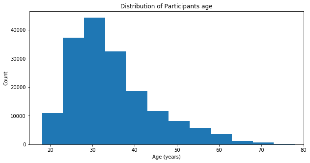

```python
bins_age = np.arange(18,141+5, 5 )
plt.figure(figsize=(10, 5))
plt.hist(data=bike, x = 'age', bins=bins_age)
plt.xlim(15,80)
#add xlabel, ylabel and title
x_y_t('Age (years)', 'Count', 'Distribution of Participants age')
plt.show()
```

```python
#remove ages more than 80 years
bike.drop(bike[(bike['age'] >80)].index, inplace=True)
```

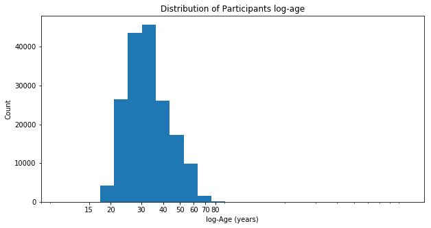

```python
bins_age = 10**np.arange(1,3+0.08, 0.08 )
plt.figure(figsize=(10, 5))
plt.hist(data=bike, x = 'age', bins=bins_age)
ticks=[15,20 , 30, 40, 50, 60,70, 80]
labels = ['{}'.format(val) for val in ticks]
plt.xscale('log')
plt.xticks(ticks,labels)
#add xlabel, ylabel and title
x_y_t('log-Age (years)', 'Count', 'Distribution of Participants log-age')

plt.show()
```

The histogram shows that the age was skewed to the right. This skewness suggests that most of the bike riders, who participated in this trip were aged between 18 and 50 years, with very few participants who were aged above 50 years. When the age was log-transformed, the data was approximately normally distributed with peaks between 25 and 45 years.

Next, we look at participants gender

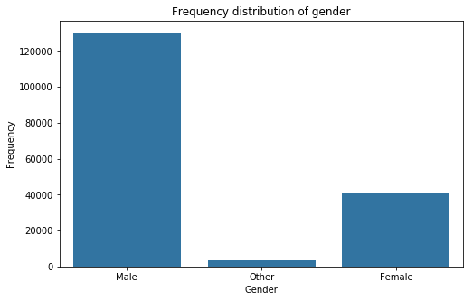

```python
#bar chart of gender
base_color = sns.color_palette()[0]

plt.figure(figsize = [8, 5])
sns.countplot(data=bike, x='member_gender', color=base_color)
#add xlabel, ylabel and title
x_y_t('Gender', 'Frequency', 'Frequency distribution of gender')
plt.show()
```

I will now look at user_type

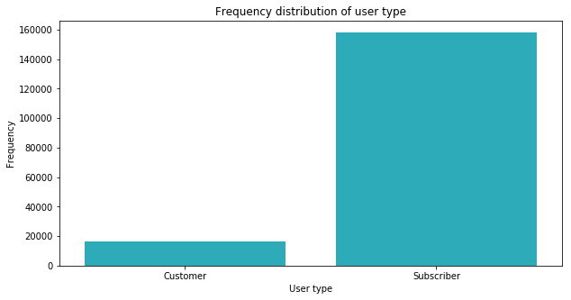

```python
base_color = sns.color_palette()[-1]
plt.figure(figsize = [10, 5])
sns.countplot(data=bike, x='user_type', color=base_color)
#add xlabel, ylabel and title
x_y_t('User type', 'Frequency', 'Frequency distribution of user type')
plt.show()
```

The bar chart shows that most of the participants in the Ford GoBike trip were subscribers rather than customers.

### Discuss the distribution(s) of your variable(s) of interest. Were there any unusual points? Did you need to perform any transformations?

> The trip duration variable was highly skewed to the right, even after limiting the distribution to 6000 seconds. However, after applying the log-transform, the data looked unimodal, with peak between 400 and 1000. In addition, the age variable was skewed to the right even after limiting the distribution to 80 years. However, on transformation using log10, the data was unimodal with peak between 25 and 45 years.

### Of the features you investigated, were there any unusual distributions? Did you perform any operations on the data to tidy, adjust, or change the form of the data? If so, why did you do this?

> When investigating the features, age showed unusual distribution, where some participants were aged above 80 years. It is very unlikely that people aged above 80 years could participate in bike riding trip. As such, any age above 80 years was considered to be an outlier and removed from the analysis.

## Bivariate Exploration

> In this section, I investigated the relationships between pairs of variables the clean data. These variables were introduced in the univariate analysis and included trip duration, age, gender, user type and trip start day.

I'll look at the relationship between trip duration and age

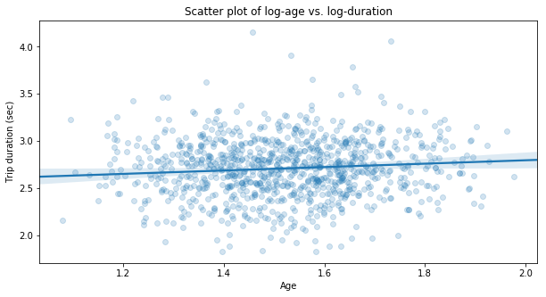

```python
#A scatter plot of age and duration_sec with log transform on both age and duration
plt.figure(figsize=(10,5))
bike_sub=bike.sample(1000, replace=False)
def log_trans(x, inverse=False):
    if not inverse:
        return np.log10(x)
    else:
        return np.power(10, x)
sns.regplot(bike_sub['age'].apply(log_trans), bike_sub['duration_sec'].apply(log_trans),  scatter_kws={'alpha':1/5}, x_jitter=0.2)
#add xlabel, ylabel and title
x_y_t('Age', 'Trip duration (sec)', 'Scatter plot of log-age vs. log-duration')
plt.show()
```

I'll look at relationship between trip duration and user type

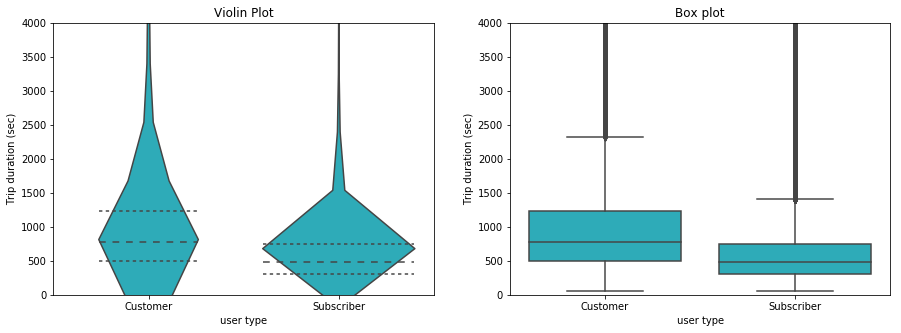

```python
base_col=sns.color_palette()[-1]
plt.figure(figsize=(15, 5))
#subplot showing violin plot
plt.subplot(1,2,1)
sns.violinplot(bike['user_type'], bike['duration_sec'], color=base_col, inner='quartile')
#add xlabel, ylabel and title
x_y_t('user type', 'Trip duration (sec)', 'Violin Plot')
#set y limit to 4000 sec to eliminate the effects of outliers
plt.ylim(0, 4000)

#subplot showing box plot
plt.subplot(1,2,2)
sns.boxplot(bike['user_type'], bike['duration_sec'], color=base_col)
#add xlabel, ylabel and title
x_y_t('user type', 'Trip duration (sec)', 'Box plot')
#set y limit to 4000 sec to eliminate the effects of outliers
plt.ylim(0, 4000)
plt.show()
```

> Based on the violin and box plots, it is clear that subscribers took lesser time to complete the trip than customers.

Next, I look at the relationship between age and user type

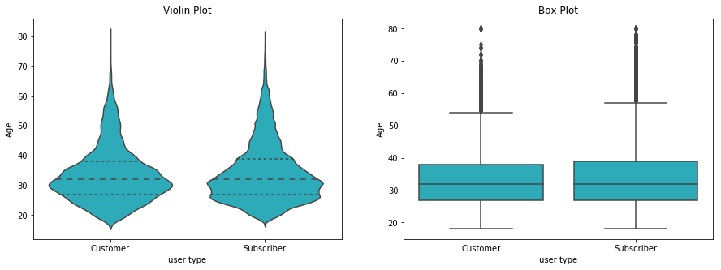

```python
base_col=sns.color_palette()[-1]
plt.figure(figsize=(15, 5))
plt.subplot(1, 2, 1)
sns.violinplot(bike['user_type'], bike['age'], color=base_col, inner='quartile')
#add xlabel, ylabel and title
x_y_t('user type', 'Age', 'Violin Plot')

plt.subplot(1,2,2)
sns.boxplot(bike['user_type'], bike['age'], color=base_col)
#add xlabel, ylabel and title
x_y_t('user type', 'Age', 'Box Plot')

plt.show()
```

> The violin plots and box plots shows that there was no difference in age between customers and subscribers.

I'll now investigate relationship between gender and duration in seconds

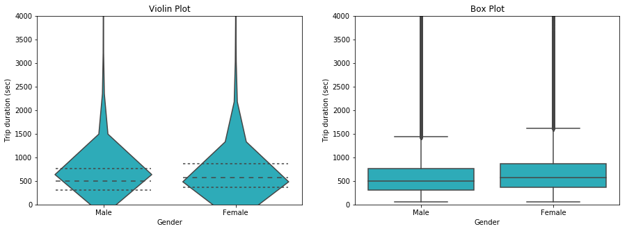

```python
#filter bike data to only records where gender is male or female
gen_bike =bike[bike['member_gender'].isin(['Male', 'Female'])]
#set the color
base_col=sns.color_palette()[-1]
plt.figure(figsize=(15, 5))
#subplot showing violin plot
plt.subplot(1, 2, 1)
sns.violinplot(gen_bike['member_gender'], gen_bike['duration_sec'], color=base_col, inner='quartile')
#set the limit to 4000 sec to reduce the effects of outliers
plt.ylim(0, 4000)
#add xlabel, ylabel and title
x_y_t('Gender', 'Trip duration (sec)', 'Violin Plot')

plt.subplot(1,2,2)
sns.boxplot(gen_bike['member_gender'], gen_bike['duration_sec'], color=base_col)
#set the limit to 4000 sec to reduce the effects of outliers
plt.ylim(0, 4000)
#add xlabel, ylabel and title
x_y_t('Gender', 'Trip duration (sec)', 'Box Plot')

plt.show()
```

> We also examined the association between gender and trip duration. Based on the violin and box plots, male participants appear to complete the trip faster than females.

Next, I look at the relationship between trip duration and start day

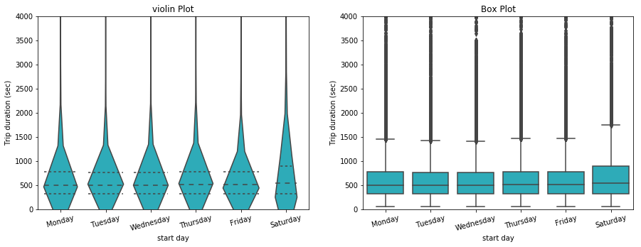

```python
plt.figure(figsize=(15,5))
#subplot showing violin plot
plt.subplot(1,2,1)
sns.violinplot(bike['start_day'], bike['duration_sec'], color=base_col, inner='quartile')
plt.xticks(rotation=15)
#set the limit to 4000 sec to reduce the effects of outliers
plt.ylim(0, 4000)
#add xlabel, ylabel and title
x_y_t('start day', 'Trip duration (sec)', 'violin Plot')


# subplot showing box plot
plt.subplot(1,2,2)
sns.boxplot(bike['start_day'], bike['duration_sec'], color=base_col)
plt.xticks(rotation=15)
#set the limit to 4000 sec to reduce the effects of outliers
plt.ylim(0, 4000)
#add xlabel, ylabel and title
x_y_t('start day', 'Trip duration (sec)', 'Box Plot')

plt.show()
```

> On examining the relationship between start day and duration in seconds, the violin plots showed that there was no much difference in trip duration among the trip start days. However, the box plot showed that participants took more time to complete the trip on saturdays than other days of the week.

I'll look at the trip duration distribution across start days

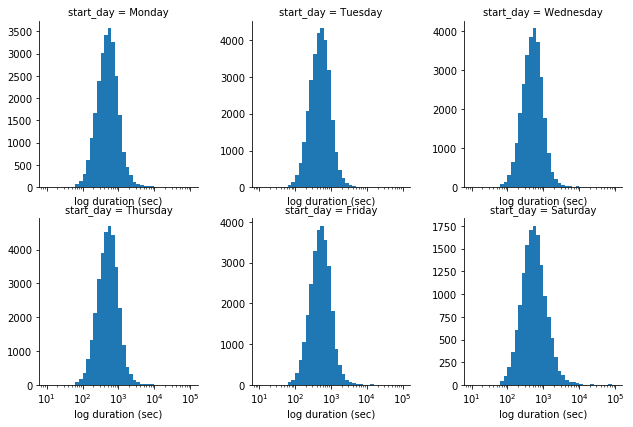

```python
bins= 10**np.arange(1, 5+0.1, 0.1)
g=sns.FacetGrid(data=bike, col='start_day', col_wrap=3, sharey=False)
g.map(plt.hist, "duration_sec", bins =bins)
g.set(xlabel='log duration (sec)')
plt.xscale('log')

plt.show()
```

> We also examined the distribution of trip duration across the various start days. In this case, the trip duration(sec) was log-transformed to remove the effects of skewness. Based on the plots, the trip duration after log transformation seemed to be normally distributed across the six starting days. This implies that there were no difference in the amount of time taken to complete the trip among the various start days.

Next, I look at the relationship between gender and user_type

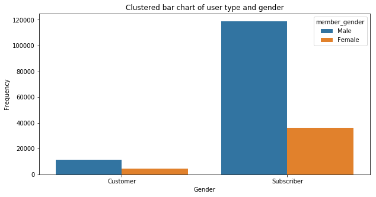

```python
plt.figure(figsize=(10,5))
#plot a clustered bar chart of user type by gender
sns.countplot(data=gen_bike, x ='user_type', hue='member_gender')
#add xlabel, ylabel and title
x_y_t('Gender', 'Frequency', 'Clustered bar chart of user type and gender')
plt.show()
```

> The clustered bar chart shows that there is an association between gender and user type. In particular, there were more males than females both in the customer and subscriber category.

Next, I look at the association between bike share for all trips and trip duration

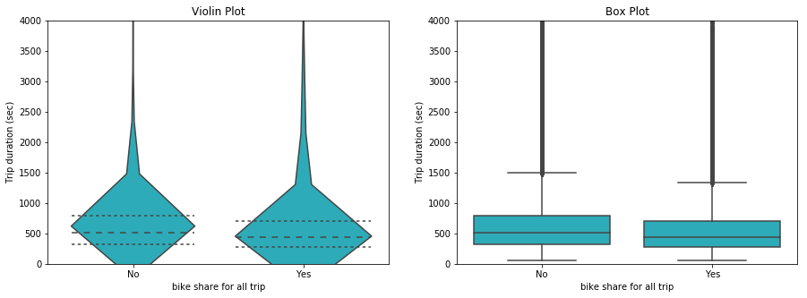

```python
plt.figure(figsize=(15,5))
#subplot showing violin plot
plt.subplot(1,2,1)
sns.violinplot(bike['bike_share_for_all_trip'], bike['duration_sec'], color=base_col, inner='quartile')
#set the y limit to 4000 seconds to remove the effects of outliers
plt.ylim(0,4000)
#add xlabel, ylabel and title
x_y_t('bike share for all trip', 'Trip duration (sec)', 'Violin Plot')

#subplot showing box plot
plt.subplot(1,2,2)
sns.boxplot(bike['bike_share_for_all_trip'], bike['duration_sec'], color=base_col)
#set the y limit to 4000 seconds to remove the effects of outliers
plt.ylim(0,4000)
#add xlabel, ylabel and title
x_y_t('bike share for all trip', 'Trip duration (sec)', 'Box Plot')
plt.show()
```

> The violin plot shows that there is no significant difference in trip duration between those that shared the bike and those who did not. However, the box plot showed that those who shared bike took slightly lesser time than those who did not share the bikes.

### Talk about some of the relationships you observed in this part of the investigation. How did the feature(s) of interest vary with other features in the dataset?

> Bivariate visualization showed a weak positive linear relationship between age and trip duration. This was as expected because young participants are more likely to ride faster than older participants. The analysis also showed that individuals who were bike customers took slightly more time to complete the trip compared to subscribers. The bivariate visualization also revealed no difference in age between customers and subscribers. This suggests that there was no difference in age distribution between customers and subscribers. We also found that the trib took approximately equal amount of time on average across the six starting days. Moreover, bivariate analysis showed that the number of customers and subscibers was high among males than among females.

### Did you observe any interesting relationships between the other features (not the main feature(s) of interest)?

> Basides the main features of interest, this study examined the association between bike share for all trips and duration in seconds. The results showed that those who shared bike took slightly lesser time than those who did not share the bikes.

## Multivariate Exploration

> In this section, I created plots of three or more variables to investigate data further. These investigations were based on findings from bivariate analysis. In particular, I explored how gender, user type and start day influence the relationship between age and trip duration. I also investigated how gender, and user type influenced trip duration.

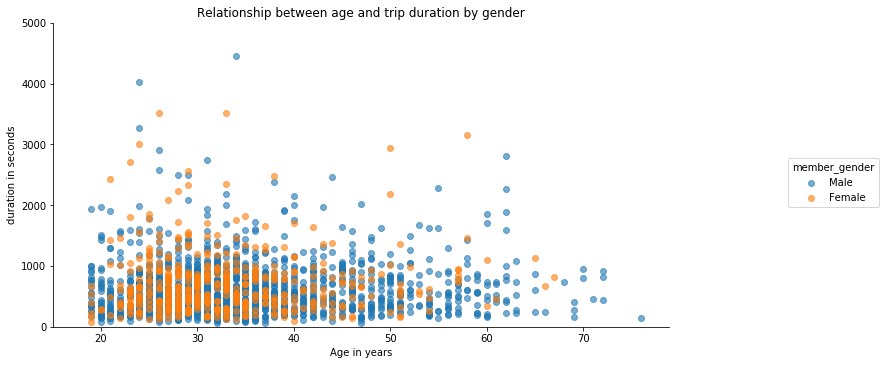

```python
#draw a sample of 2000 for clarity
sample_data=gen_bike.sample(n=2000, replace = False)
#scatter plot of age vs duration by gender
g = sns.FacetGrid(data = sample_data, hue = 'member_gender', size = 5)
g.map(plt.scatter, 'age', 'duration_sec', alpha=0.6)
g.add_legend()
g.set(ylim=(0,5000))
## Set Plot Dimensions - FIGURE LEVEL
g.fig.set_size_inches(14, 5)
#add xlabel, ylabel and title
x_y_t('Age in years', 'duration in seconds', 'Relationship between age and trip duration by gender')
plt.show()
```

> The scatter plot to investigate the relationship between age and duration in seconds by gender shows that there is an interaction between male and female ages but no interaction with trip duration.

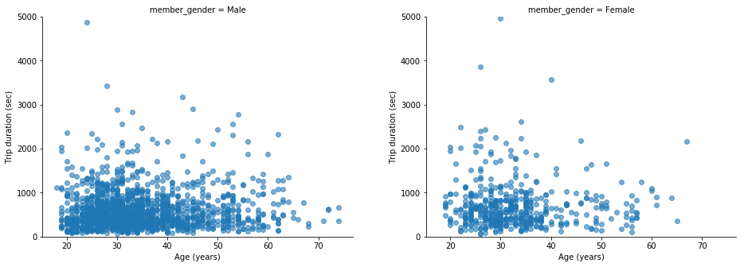

```python
#draw a sample of 2000 for clarity
sample_data=gen_bike.sample(n=2000, replace = False)
#scatter plot of age and trip duration faceted by gender
g = sns.FacetGrid(data = sample_data, col = 'member_gender', size = 4)
g.map(plt.scatter, 'age', 'duration_sec', alpha=0.6)
g.set(ylabel='Trip duration (sec)')
g.set(xlabel='Age (years)')
g.set(ylim=(0,5000))
## Set Plot Dimensions - FIGURE LEVEL
g.fig.set_size_inches(14, 5)
plt.show()
```

> We also investigated the relationship between age and trip duration after faceting by gender. The results showed a weak linear relationship between trip duration and age for male and females.

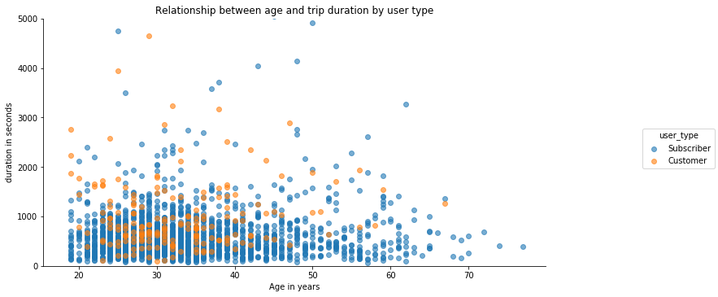

```python
#draw a sample of 2000 for clear visual
sample_data=bike.sample(n=2000, replace = False)
#scatter plot of age vs duration by user type
g = sns.FacetGrid(data = sample_data, hue = 'user_type', size = 5)
g.map(plt.scatter, 'age', 'duration_sec', alpha=0.6)
g.add_legend()
g.set(ylim=(0,5000))
## Set Plot Dimensions - FIGURE LEVEL
g.fig.set_size_inches(14, 5)
#add xlabel, ylabel and title
x_y_t('Age in years', 'duration in seconds', 'Relationship between age and trip duration by user type')

plt.show()
```

> The scatter plot to investigate the relationship between age and duration in seconds by user type shows that there is an interaction between customers and subscribers but no interaction with trip duration. However, customers seems to take more time to complete the trip compared to subscribers.

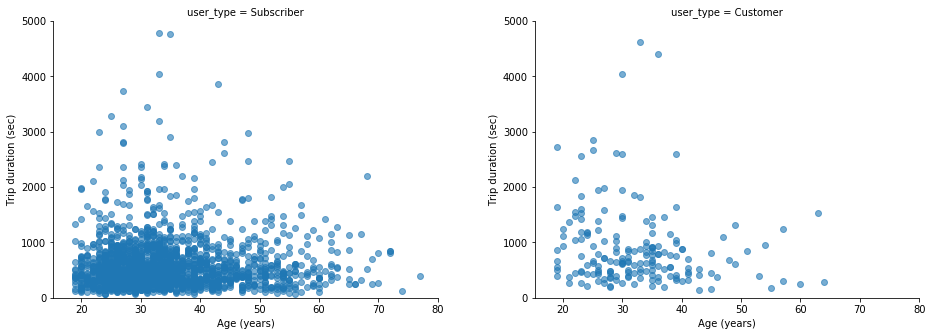

```python
#draw a sample of 2000 for clear visual
sample_data=bike.sample(n=2000, replace = False)

#scatter plot of age vs trip duration faceted by user type
g = sns.FacetGrid(data = sample_data, col = 'user_type', size = 4)
g.map(plt.scatter, 'age', 'duration_sec',  alpha=0.6)
g.set(ylabel='Trip duration (sec)')
g.set(xlabel='Age (years)')
g.set(ylim=(0,5000))
## Set Plot Dimensions - FIGURE LEVEL
g.fig.set_size_inches(14, 5)
plt.show()
```

> When a scatter plot of age vs trip duration is plotted and faceted by user type, there seems to be a weak relationship between age and trip duration between age and trip duration (sec). However, the correlation seems to be much stronger among customer than subscribers.

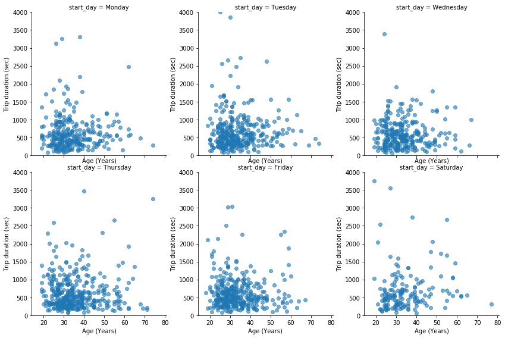

```python
#draw a sample of 2000 for clear visual
sample_data=bike.sample(n=2000, replace = False)
#scatter plot of age vs. trip duration faceted by start day
g = sns.FacetGrid(data = sample_data, col = 'start_day', size = 4, col_wrap=3, sharey=False)
g.map(plt.scatter, 'age', 'duration_sec', alpha =0.6)
g.set(ylim=(0, 4000))
g.set(ylabel='Trip duration (sec)')
g.set(xlabel='Age (Years)')


plt.show()
```

> We also investigated the relationship between participant's age and trip duration across the six trip days. The results showed that there was a weak linear relationship between age and trip duration across the six starting days. In other words, there was a similar relationship between age and trip duration across the six days. Suprisingly, the correlation seems to be much stronger on Monday and Saturday than on other days.

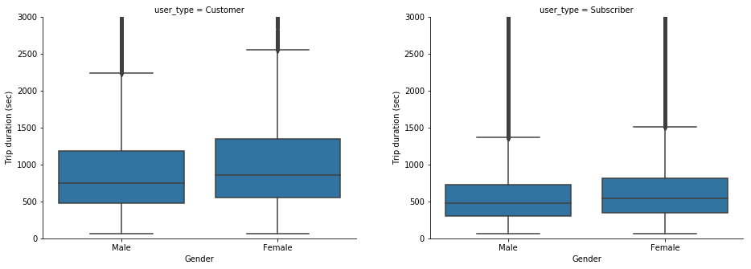

```python
g = sns.FacetGrid(data = gen_bike, col = 'user_type', size = 4)
g.map(sns.boxplot, 'member_gender', 'duration_sec')
g.set(ylim=(0,3000))
g.set(ylabel='Trip duration (sec)')
g.set(xlabel='Gender')
## Set Plot Dimensions - FIGURE LEVEL
g.fig.set_size_inches(14, 5)

plt.show()
```

> We also investigated the relationship between user type, gender and trip duration. Based on the box plot, it was evident that among the participants who were customers, male completed the trip faster than females. Similarly, the box plot shows a slight difference in trip duration between males and females, based on the participants who were subscribers. Thus, regardless of the user type, male participants took lesser time to complete the trip than females.

### Talk about some of the relationships you observed in this part of the investigation. Were there features that strengthened each other in terms of looking at your feature(s) of interest?

> The multivariate exploration showed a weak linear relationship between age and trip duration for both males and females. we also found a stronger linear relationship between age and trip duration among customers than subscribers. Additionally, the results revealed that conditioned on user type, male participants took lesser time to complete the trip than females.

### Were there any interesting or surprising interactions between features?

> Suprising interactions was found between age, trip duration and start days. In particular, the relationship between age and trip duration was slightly stronger on Monday and Saturday than on other days.